# STAT-627 Celestial Classification

## Logistic regression

Since there are three classes, we will create a separate logistic model for each. Then our prediction will be the class that has the highest probability.

### 1. Define individual logistic models

```r
# Calculate individual logistic models for each celestial object
galaxy.mod <- glm(galaxy ~ u + g + r + i + z + trans.redshift, data = Space_DF, family = binomial)
star.mod <- glm(star ~ u + g + r + i + z + trans.redshift, data = Space_DF, family = binomial)
quasar.mod <- glm(quasar ~ u + g + r + i + z + trans.redshift, data = Space_DF, family = binomial)

summary(galaxy.mod)
```

```
##
## Call:
## glm(formula = galaxy ~ u + g + r + i + z + trans.redshift, family = binomial,
##     data = Space_DF)
##
## Deviance Residuals:
##     Min       1Q   Median       3Q      Max
## -6.1698  -0.7190   0.3692   0.6542   6.1750
##
## Coefficients:
##                 Estimate Std. Error z value Pr(>|z|)
## (Intercept)     3.673411   0.104469  35.163  < 2e-16 ***
## u               0.009483   0.009302   1.019    0.308
## g               1.833326   0.025331  72.375  < 2e-16 ***
## r              -0.748329   0.039355 -19.015  < 2e-16 ***
## i              -1.276520   0.039100 -32.648  < 2e-16 ***
## z              -0.143812   0.024542  -5.860 4.64e-09 ***
## trans.redshift  1.101440   0.021668  50.833  < 2e-16 ***
## ---
## Signif. codes:  0 '***' 0.001 '**' 0.01 '*' 0.05 '.' 0.1 ' ' 1
##
## (Dispersion parameter for binomial family taken to be 1)
##
##     Null deviance: 135038  on 99998  degrees of freedom
## Residual deviance:  91123  on 99992  degrees of freedom
## AIC: 91137
##
## Number of Fisher Scoring iterations: 5
```

```r
summary(star.mod)
```

```
##
## Call:
## glm(formula = star ~ u + g + r + i + z + trans.redshift, family = binomial,
##     data = Space_DF)
##
## Deviance Residuals:
##    Min      1Q  Median      3Q     Max
## -4.231   0.000   0.000   0.000   1.589
##
## Coefficients:
##                 Estimate Std. Error z value Pr(>|z|)
## (Intercept)      6.22519    0.44807  13.893  < 2e-16 ***
## u                0.19731    0.04305   4.583 4.58e-06 ***
## g               -0.42816    0.06621  -6.466 1.00e-10 ***
## r                0.18803    0.09861   1.907   0.0565 .
## i               -0.11858    0.10634  -1.115   0.2648
## z                0.02656    0.06624   0.401   0.6885
## trans.redshift -55.27202    1.31128 -42.151  < 2e-16 ***
## ---
## Signif. codes:  0 '***' 0.001 '**' 0.01 '*' 0.05 '.' 0.1 ' ' 1
##
## (Dispersion parameter for binomial family taken to be 1)
##
##     Null deviance: 104341.2  on 99998  degrees of freedom
## Residual deviance:   4983.7  on 99992  degrees of freedom
## AIC: 4997.7
##
## Number of Fisher Scoring iterations: 13
```

```r
summary(quasar.mod)
```

```
##
## Call:
## glm(formula = quasar ~ u + g + r + i + z + trans.redshift, family = binomial,
##     data = Space_DF)
##
## Deviance Residuals:
##     Min       1Q   Median       3Q      Max
## -6.1556  -0.1736  -0.0946  -0.0108   5.0969
##
## Coefficients:
##                Estimate Std. Error z value Pr(>|z|)
## (Intercept)    10.06886    0.32843  30.658  < 2e-16 ***
## u              -0.48011    0.02400 -20.003  < 2e-16 ***
## g              -1.18949    0.04554 -26.118  < 2e-16 ***
## r              -0.50163    0.06190  -8.104 5.31e-16 ***
## i               1.13130    0.05812  19.466  < 2e-16 ***
## z               0.19773    0.03933   5.028 4.96e-07 ***
## trans.redshift 10.17163    0.13264  76.686  < 2e-16 ***
## ---
## Signif. codes:  0 '***' 0.001 '**' 0.01 '*' 0.05 '.' 0.1 ' ' 1
##
## (Dispersion parameter for binomial family taken to be 1)
##
##     Null deviance: 97131  on 99998  degrees of freedom
## Residual deviance: 19338  on 99992  degrees of freedom
## AIC: 19352
##
## Number of Fisher Scoring iterations: 8
```

### 2. Select best subset

```r
# criteria
library(leaps)
criteria <- NULL
for(Y in list(Space_DF$galaxy, Space_DF$star, Space_DF$quasar)){
  subsets <- regsubsets(Y ~ u + g + r + i + z + redshift, data = Space_DF)
  criteria <- rbind(criteria,
                    -summary(subsets)$adjr2, # converted to negative so that best is minimum
                    summary(subsets)$bic,
                    abs(summary(subsets)$cp - 1:6)) # absolute difference so that best is minimum
}
criteria <- as.data.frame(criteria)
rownames(criteria) <- c("-adjR2 (galaxy)", "BIC (galaxy)", "|Cp - p| (galaxy)",
                        "-adjR2 (star)", "BIC (star)", "|Cp - p| (star)",
                        "-adjR2 (quasar)", "BIC (quasar)", "|Cp - p| (quasar)")
criteria$best <- apply(criteria, 1, which.min)
criteria
```

```
##                              V1            V2            V3            V4
## -adjR2 (galaxy)   -7.426029e-02 -3.421361e-01 -3.497157e-01 -3.529099e-01
## BIC (galaxy)      -7.694114e+03 -4.184277e+04 -4.299108e+04 -4.347298e+04
## |Cp - p| (galaxy)  4.387835e+04  2.246252e+03  1.068272e+03  5.718438e+02
## -adjR2 (star)     -1.715857e-01 -1.937973e-01 -2.783604e-01 -2.827546e-01
## BIC (star)        -1.880198e+04 -2.150925e+04 -3.257957e+04 -3.317982e+04
## |Cp - p| (star)    1.587596e+04  1.276905e+04  9.411477e+02  3.265430e+02
## -adjR2 (quasar)   -5.725123e-01 -6.321367e-01 -6.789295e-01 -6.870639e-01
## BIC (quasar)      -8.496010e+04 -9.997086e+04 -1.135653e+05 -1.161209e+05
## |Cp - p| (quasar)  3.687711e+04  1.778636e+04  2.804367e+03  1.999286e+02
##                              V5            V6 best
## -adjR2 (galaxy)   -3.549244e-01 -3.565830e-01    6
## BIC (galaxy)      -4.377426e+04 -4.402120e+04    6
## |Cp - p| (galaxy)  2.587731e+02  1.000000e+00    6
## -adjR2 (star)     -2.839598e-01 -2.850821e-01    6
## BIC (star)        -3.333749e+04 -3.348383e+04    6
## |Cp - p| (star)    1.579608e+02  1.000000e+00    6
## -adjR2 (quasar)   -6.876236e-01 -6.876853e-01    6
## BIC (quasar)      -1.162894e+05 -1.162986e+05    6
## |Cp - p| (quasar)  2.073915e+01  1.000000e+00    6
```

```r
# stepwise
full <- galaxy.mod
null <- glm(galaxy ~ 1, data = Space_DF, family = binomial)
stats::step(null, scope = list(lower = null, upper = full), direction = "forward", trace = 0)
```

```
##
## Call:  glm(formula = galaxy ~ u + z + g + i + trans.redshift + r, family = binomial,
##     data = Space_DF)
##
## Coefficients:
##    (Intercept)               u               z               g               i
##       3.673411        0.009483       -0.143812        1.833326       -1.276520
## trans.redshift               r
##       1.101440       -0.748329
##
## Degrees of Freedom: 99998 Total (i.e. Null);  99992 Residual
## Null Deviance:       135000
## Residual Deviance: 91120     AIC: 91140
```

```r
stats::step(full, scope = list(lower = null, upper = full), direction = "backward", trace = 0)
```

```
##
## Call:  glm(formula = galaxy ~ g + r + i + z + trans.redshift, family = binomial,
##     data = Space_DF)
##
## Coefficients:
##    (Intercept)               g               r               i               z
##         3.7001          1.8503         -0.7547         -1.2802         -0.1422
## trans.redshift
##         1.0997
##
## Degrees of Freedom: 99998 Total (i.e. Null);  99993 Residual
## Null Deviance:       135000
## Residual Deviance: 91120     AIC: 91140
```

### 3. Cross-validation

```r
cv.logistic <- function(train, test, predictors){
  # This function trains a logistic model for each type of celestial object, then
  # predicts the type of celestial object based on which one is most probable

  # Inputs
    # train: A training data set
    # test: A testing data set
    # predictors: The names of predictors to include in the model

  # Outputs

  formula <- list(as.formula(paste("galaxy ~", paste(predictors, collapse = "+"))),
                  as.formula(paste("star ~", paste(predictors, collapse = "+"))),
                  as.formula(paste("quasar ~", paste(predictors, collapse = "+"))))

  mod <- list(galaxy = glm(formula[[1]], data = train, family = binomial),
              star = glm(formula[[2]], data = train, family = binomial),
              quasar = glm(formula[[3]], data = train, family = binomial))

  pred <- data.frame(GALAXY = predict(mod$galaxy, newdata = test, type = "response"),
                     STAR = predict(mod$star, newdata = test, type = "response"),
                     QSO = predict(mod$quasar, newdata = test, type = "response"))

  pred$class <- apply(pred, 1, function(x) names(which.max(x)))

  return(list(predictions = pred,
              class.rate = mean(pred$class == test$class),
              confusion.matrix = table(pred$class, test$class)))

}
```

```r
# cross-validation
predictors <- c("u", "g", "r", "i", "z", "trans.redshift")

VS <- cv.logistic(S.Train, S.Test, predictors)
CV.results["Logistic", "ValSet"] <- VS$class.rate
VS$confusion.matrix
```

```
##
##          GALAXY  QSO STAR
##   GALAXY   5651  168   22
##   QSO       186 1705    0
##   STAR       51    0 2217
```

```r
# 10-fold
class.rates <- NULL

for(i in 1:10){
  train <- Space_DF[fold != i,]
  test <- Space_DF[fold == i,]
  KF <- cv.logistic(train, test, predictors)
  class.rates <- c(class.rates, KF$class.rate)
}

CV.results["Logistic", "KFold"] <- mean(class.rates)
```

### 4. Logistic regression with principle components

```r
# cross-validation
predictors <- c("PC1", "PC2", "PC3")

VS <- cv.logistic(S.Train.PC, S.Test.PC, predictors)
CV.results["Logistic.PC", "ValSet"] <- VS$class.rate
VS$confusion.matrix
```

```
##
##          GALAXY  QSO STAR
##   GALAXY   5657  188   10
##   QSO       183 1685    0
##   STAR       48    0 2229
```

```r
# 10-fold

class.rates <- NULL

for(i in 1:10){
  train <- pc_df[fold != i,]
  test <- pc_df[fold == i,]
  KF <- cv.logistic(train, test, predictors)
  class.rates <- c(class.rates, KF$class.rate)
}

CV.results["Logistic.PC", "KFold"] <- mean(class.rates)
```

### Understanding the results

Logistic regression has a classification rate of about 95.6% - 95.7%, slightly less than KNN. Logistic regression with principal components was just as accurate as regular logistic regression, so for this model using principal components to reduce the data set size is advantageous.

## Trees/Random Forests

### Single Tree

```r
# train model and plot
tree <- tree(class ~ u + g + r + i + z + redshift, S.Train)
y_hat <- predict(tree, newdata = S.Test, type = 'class')
tree
```

```
## node), split, n, deviance, yval, (yprob)
##       * denotes terminal node
##
##  1) root 89999 171900 GALAXY ( 0.5950844 0.1898688 0.2150468 )
##    2) redshift < 0.00417124 19824   4482 STAR ( 0.0235573 0.0001513 0.9762914 ) *
##    3) redshift > 0.00417124 70175  77900 GALAXY ( 0.7565372 0.2434628 0.0000000 )
##      6) redshift < 0.9937 55648  25600 GALAXY ( 0.9389017 0.0610983 0.0000000 )
##       12) redshift < 0.673369 46235  13790 GALAXY ( 0.9657619 0.0342381 0.0000000 ) *
##       13) redshift > 0.673369 9413   9236 GALAXY ( 0.8069691 0.1930309 0.0000000 )
##         26) g < 21.7544 1968   2187 QSO ( 0.2439024 0.7560976 0.0000000 ) *
##         27) g > 21.7544 7445   2696 GALAXY ( 0.9558093 0.0441907 0.0000000 ) *
##      7) redshift > 0.9937 14527   6430 QSO ( 0.0579610 0.9420390 0.0000000 )
##       14) g < 22.1438 12675   1982 QSO ( 0.0150690 0.9849310 0.0000000 ) *
##       15) g > 22.1438 1852   2402 QSO ( 0.3515119 0.6484881 0.0000000 ) *
```

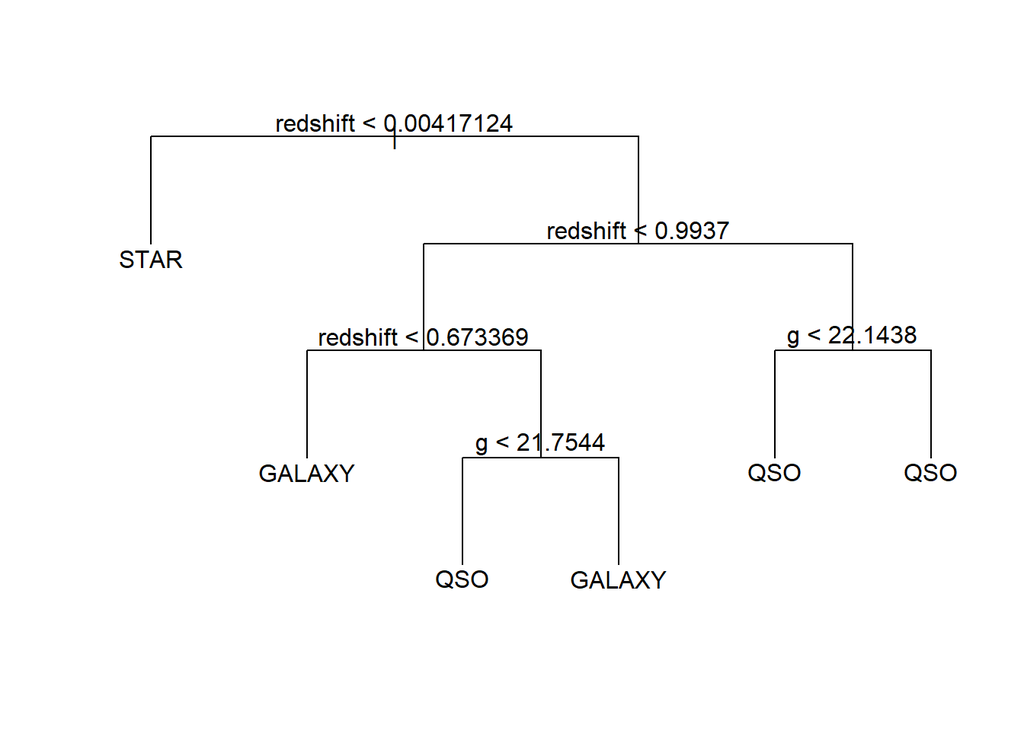

```r
plot(tree, type = 'uniform'); text(tree)
```

```r
# show performance on testing data
CV.results["Tree", "ValSet"] <- mean(y_hat == Y.S.Test)
table(y_hat, Y.S.Test)
```

```
##         Y.S.Test
## y_hat    GALAXY  QSO STAR
##   GALAXY   5692  237    0
##   QSO       150 1636    0
##   STAR       46    0 2239
```

The single tree classifies celestial bodies based on two predictors: redshift and g, with the former being the dominant predictor in the tree. Redshift is the only predictor that is used to classify stars. Very low redshift values correspond to stars, and very high redshift values correspond to quasars (though this is done with varying degrees of confidence depending on the g value). The middle range of redshift values can be split to classify galaxies on the lower end, and on the higher end it classifies into either galaxies or quasars, with g differentiating between the two with a redshift greater than 0.673369.

The performance is quite good, with a prediction accuracy of 95.67%.

```r
# train model and plot
tree <- tree(class ~ u + g + r + i + z + redshift, Space_DF)
tree.cv <- cv.tree(tree, FUN = prune.misclass)
tree.cv.size <- tree.cv$size[which.min(tree.cv$dev)]
tree.pruned <- prune.misclass(tree, best = tree.cv.size)
tree.pruned
```

```
## node), split, n, deviance, yval, (yprob)
##       * denotes terminal node
##
##  1) root 99999 191100 GALAXY ( 0.5944559 0.1896119 0.2159322 )
##    2) redshift < 0.00417124 22109   4935 STAR ( 0.0232032 0.0001357 0.9766611 ) *
##    3) redshift > 0.00417124 77890  86450 GALAXY ( 0.7566055 0.2433945 0.0000000 )
##      6) redshift < 1.00104 61920  28940 GALAXY ( 0.9375323 0.0624677 0.0000000 )
##       12) redshift < 0.684613 51917  15810 GALAXY ( 0.9648477 0.0351523 0.0000000 ) *
##       13) redshift > 0.684613 10003  10130 GALAXY ( 0.7957613 0.2042387 0.0000000 )
##         26) g < 21.7903 2198   2403 QSO ( 0.2361237 0.7638763 0.0000000 ) *
##         27) g > 21.7903 7805   2942 GALAXY ( 0.9533632 0.0466368 0.0000000 ) *
##      7) redshift > 1.00104 15970   6812 QSO ( 0.0551033 0.9448967 0.0000000 )
##       14) g < 22.2081 14146   2277 QSO ( 0.0156228 0.9843772 0.0000000 ) *
##       15) g > 22.2081 1824   2386 QSO ( 0.3612939 0.6387061 0.0000000 ) *
```

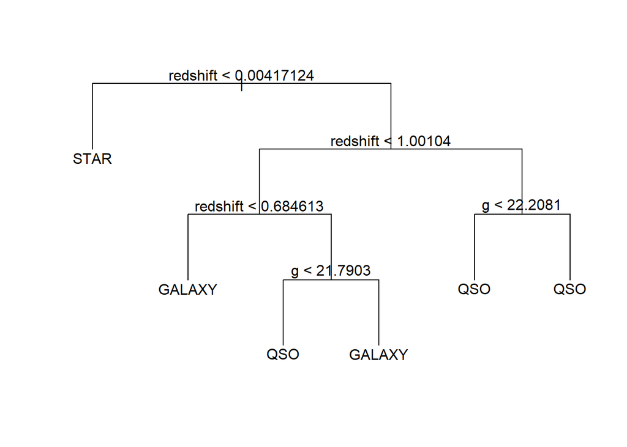

```r
plot(tree.pruned, type = 'uniform'); text(tree.pruned)
```

```r
# show performance of model
tree.pruned.s <- summary(tree.pruned)
CV.results["Tree", "KFold"] <- 1 - tree.pruned.s[[7]][1] / tree.pruned.s[[7]][2]
```

Model performance improves when applying K-Fold cross validation, with a prediction accuracy of approximately 95.9%. The same predictors are used.

```r
# train model and plot
tree <- tree(class ~ PC1 + PC2 + PC3, S.Train.PC)
y_hat <- predict(tree, newdata = S.Test.PC, type = 'class')
tree
```

```
## node), split, n, deviance, yval, (yprob)
##       * denotes terminal node
##
##  1) root 89999 171900 GALAXY ( 0.5950844 0.1898688 0.2150468 )
##    2) PC2 < 0.655973 73974 101900 GALAXY ( 0.7126693 0.0268473 0.2604834 )
##      4) PC3 < 0.182787 49365  35950 GALAXY ( 0.9036159 0.0184139 0.0779702 )
##        8) PC2 < -1.23359 1923   1218 STAR ( 0.0884035 0.0026001 0.9089964 ) *
##        9) PC2 > -1.23359 47442  26070 GALAXY ( 0.9366595 0.0190548 0.0442857 )
##         18) PC1 < 0.984047 31272   7442 GALAXY ( 0.9747378 0.0250704 0.0001919 ) *
##         19) PC1 > 0.984047 16170  13850 GALAXY ( 0.8630179 0.0074212 0.1295609 )
##           38) PC2 < -0.350603 1577   1412 STAR ( 0.1616994 0.0006341 0.8376665 ) *
##           39) PC2 > -0.350603 14593   7421 GALAXY ( 0.9388063 0.0081546 0.0530391 )
##             78) PC1 < 3.63253 11408   1452 GALAXY ( 0.9894811 0.0084151 0.0021038 ) *
##             79) PC1 > 3.63253 3185   3737 GALAXY ( 0.7572998 0.0072214 0.2354788 ) *
##      5) PC3 > 0.182787 24609  39160 STAR ( 0.3296355 0.0437645 0.6266000 )
##       10) PC2 < -0.0527734 14937  13380 STAR ( 0.1358372 0.0091049 0.8550579 )
##         20) PC1 < -1.91404 2019   3450 STAR ( 0.4596335 0.0490342 0.4913323 ) *
##         21) PC1 > -1.91404 12918   8028 STAR ( 0.0852299 0.0028642 0.9119059 ) *
##       11) PC2 > -0.0527734 9672  16890 GALAXY ( 0.6289289 0.0972911 0.2737800 )
##         22) PC1 < 2.81414 6578   7845 GALAXY ( 0.8087565 0.1427486 0.0484950 ) *
##         23) PC1 > 2.81414 3094   3489 STAR ( 0.2466063 0.0006464 0.7527473 ) *
##    3) PC2 > 0.655973 16025   7628 QSO ( 0.0522933 0.9424025 0.0053042 )
##      6) PC2 < 1.00587 2695   3702 QSO ( 0.2612245 0.7128015 0.0259740 ) *
##      7) PC2 > 1.00587 13330   1733 QSO ( 0.0100525 0.9888222 0.0011253 ) *
```

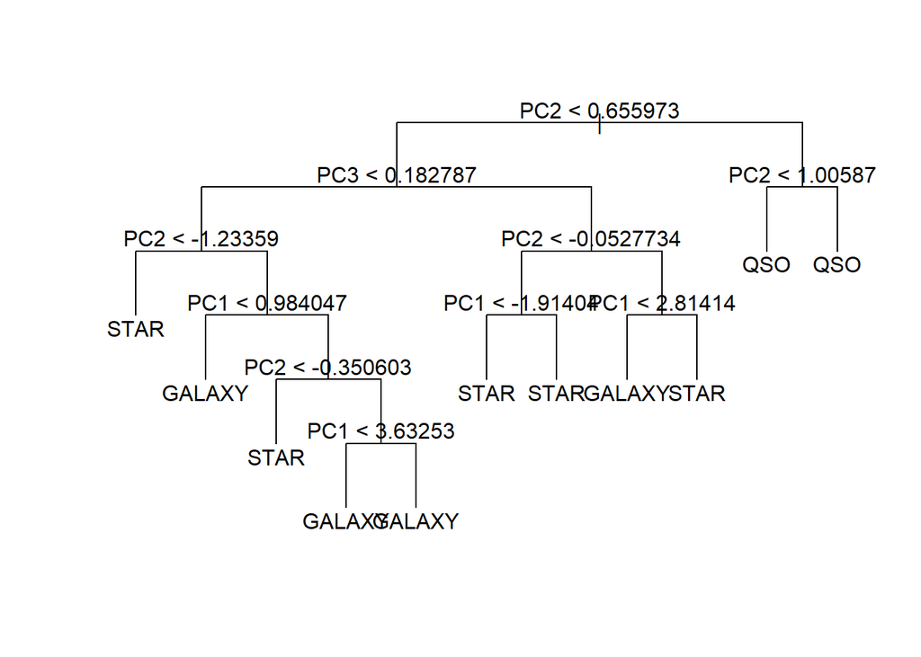

```r
plot(tree, type = 'uniform'); text(tree)
```

```r
# show performance on testing data
CV.results["Tree.PC", "ValSet"] <- mean(y_hat == Y.S.Test)
table(y_hat, Y.S.Test)
```

```
##         Y.S.Test
## y_hat    GALAXY  QSO STAR
##   GALAXY   5457  221  150
##   QSO        84 1634   12
##   STAR      347   18 2077
```

The prediction accuracy declines sharply when introducing principal components to the single pruned tree, down to 91.68%.

```r
# train model and plot
tree <- tree(class ~ PC1 + PC2 + PC3, pc_df)
tree.cv <- cv.tree(tree, FUN = prune.misclass)
tree.cv.size <- tree.cv$size[which.min(tree.cv$dev)]
tree.pruned <- prune.misclass(tree, best = tree.cv.size)
tree.pruned
```

```
## node), split, n, deviance, yval, (yprob)
##       * denotes terminal node
##
##  1) root 99999 191100 GALAXY ( 0.5944559 0.1896119 0.2159322 )
##    2) PC2 < 0.655973 82244 113600 GALAXY ( 0.7115777 0.0270536 0.2613686 )
##      4) PC3 < 0.182787 54821  39980 GALAXY ( 0.9034129 0.0184601 0.0781270 )
##        8) PC2 < -1.21534 2197   1547 STAR ( 0.1015020 0.0036413 0.8948566 ) *
##        9) PC2 > -1.21534 52624  28850 GALAXY ( 0.9368919 0.0190787 0.0440293 )
##         18) PC1 < 0.984047 34648   8281 GALAXY ( 0.9745728 0.0252540 0.0001732 ) *
##         19) PC1 > 0.984047 17976  15290 GALAXY ( 0.8642635 0.0071762 0.1285603 )
##           38) PC2 < -0.350603 1726   1576 STAR ( 0.1674392 0.0005794 0.8319815 ) *
##           39) PC2 > -0.350603 16250   8296 GALAXY ( 0.9382769 0.0078769 0.0538462 )
##             78) PC1 < 3.65066 12769   1642 GALAXY ( 0.9894275 0.0081447 0.0024278 ) *
##             79) PC1 > 3.65066 3481   4130 GALAXY ( 0.7506464 0.0068946 0.2424591 ) *
##      5) PC3 > 0.182787 27423  43650 STAR ( 0.3280823 0.0442329 0.6276848 )
##       10) PC2 < -0.0303083 17023  15590 STAR ( 0.1403983 0.0095165 0.8500852 )
##         20) PC1 < -2.03412 1885   3283 GALAXY ( 0.5161804 0.0583554 0.4254642 ) *
##         21) PC1 > -2.03412 15138  10090 STAR ( 0.0936055 0.0034351 0.9029594 ) *
##       11) PC2 > -0.0303083 10400  18120 GALAXY ( 0.6352885 0.1010577 0.2636538 )
##         22) PC1 < 2.89578 7241   8542 GALAXY ( 0.8102472 0.1447314 0.0450214 ) *
##         23) PC1 > 2.89578 3159   3485 STAR ( 0.2342513 0.0009497 0.7647990 ) *
##    3) PC2 > 0.655973 17755   8443 QSO ( 0.0519290 0.9426077 0.0054632 )
##      6) PC2 < 1.00587 3008   4142 QSO ( 0.2586436 0.7140957 0.0272606 ) *
##      7) PC2 > 1.00587 14747   1856 QSO ( 0.0097647 0.9892181 0.0010172 ) *
```

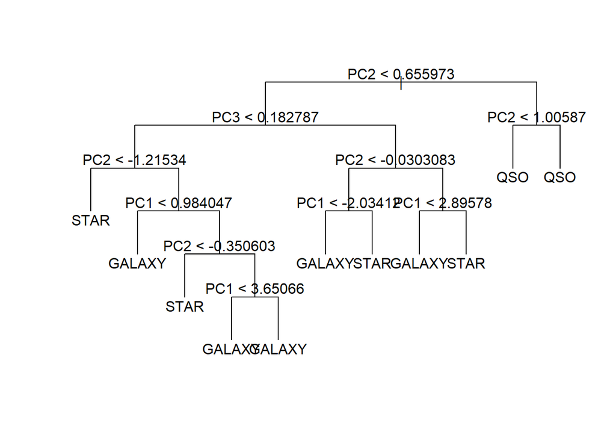

```r
plot(tree.pruned, type = 'uniform'); text(tree.pruned)
```

```r
# show performance of model
tree.pruned.s <- summary(tree.pruned)
CV.results["Tree.PC", "KFold"] <- 1 - tree.pruned.s[[6]][1] / tree.pruned.s[[6]][2]
```

Interestingly, K-Fold cross-validation continues to improve prediction accuracy. Prediction accuracy declines to approximately 92.08%.

### Random Forests

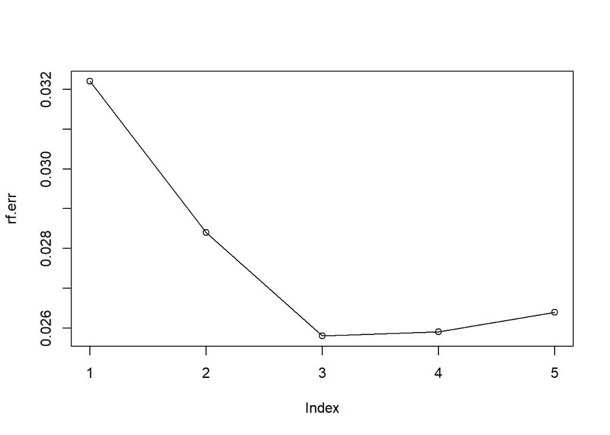

```r
set.seed(1)

# initialize error and tree number variables
rf.err <- 0
ntrees <- 0
for(i in 1:5){
  rf <- randomForest(class ~ u + g + r + i + z + redshift,
                     data = S.Train[1:5000,], mtry = i) # for tuning, we use a the first 5000 observations to reduce computing time
  rf.ntrees <- which.min(rf$err.rate)
  rf <- randomForest(class ~ u + g + r + i + z + redshift,
                     data = S.Train[1:5000,], mtry = i, ntree = rf.ntrees)
  y_hat <- predict(rf, newdata = S.Test)
  rf.err[i] <- mean(y_hat != Y.S.Test)
  ntrees[i] <- rf.ntrees
}

plot(rf.err); lines(rf.err)
```

```r
rf.optimal <- randomForest(class ~ u + g + r + i + z + redshift,
                           data = S.Train,
                           mtry = which.min(rf.err),
                           ntrees = ntrees[which.min(rf.err)]
                           )
y_hat <- predict(rf.optimal, newdata = S.Test, type = 'class')
table(y_hat, Y.S.Test)
```

```
##         Y.S.Test
## y_hat    GALAXY  QSO STAR
##   GALAXY   5811  148    1
##   QSO        71 1725    0
##   STAR        6    0 2238
```

```r
CV.results["RF", "ValSet"] <- mean(y_hat == Y.S.Test)
```

The random forest method achieves the highest prediction accuracy of all tree-based models at 97.73%.

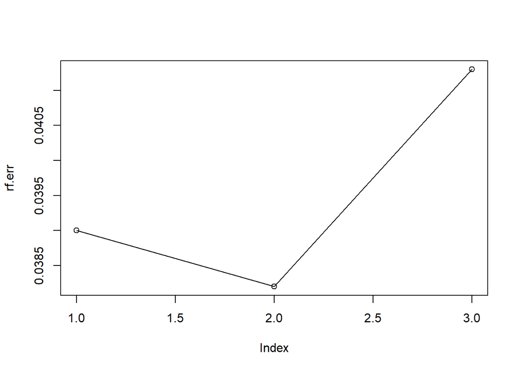

```r
set.seed(1)

# initialize error and tree number variables
rf.err <- 0
ntrees <- 0
for(i in 1:3){
  rf <- randomForest(class ~ PC1 + PC2 + PC3,
                     data = S.Train.PC[1:5000,], mtry = i)
  rf.ntrees <- which.min(rf$err.rate)
  rf <- randomForest(class ~ PC1 + PC2 + PC3,
                     data = S.Train.PC[1:5000,], mtry = i, ntree = rf.ntrees)
  y_hat <- predict(rf, newdata = S.Test.PC)
  rf.err[i] <- mean(y_hat != Y.S.Test)
  ntrees[i] <- rf.ntrees
}

plot(rf.err); lines(rf.err)
```

```r
rf.optimal <- randomForest(class ~ PC1 + PC2 + PC3,
                           data = S.Train.PC,
                           mtry = which.min(rf.err),
                           ntrees = ntrees[which.min(rf.err)]
                           )
y_hat <- predict(rf.optimal, newdata = S.Test.PC, type = 'class')
table(y_hat, Y.S.Test)
```

```
##         Y.S.Test
## y_hat    GALAXY  QSO STAR
##   GALAXY   5759  194    4
##   QSO        80 1677    0
##   STAR       49    2 2235
```

```r
CV.results["RF.PC", "ValSet"] <- mean(y_hat == Y.S.Test)
```

Remaining consistent with prior models, principal components in the random forest model decrease prediction accuracy to 96.73%.

In summary, principal components reduce the prediction accuracy of the tree-based models. One of the reasons is likely that the trees eliminate the multicolinearity issue introduced by the highly correlated wavelength variables by including only one them in conjunction with the redshift variable. Thus, where elimination of multicolinearity is an advantage of principal components, this is redundant when considering decision trees.

Furthermore, random forests are able to achieve a higher prediction accuracy by considering all wavelength variables. This is a significant advantage over a single tree, which only ever considers one wavelength.

# Results

## Model comparison

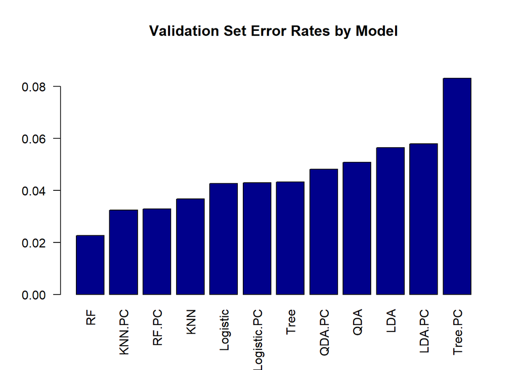

```r
CV.err <- (1 - CV.results)[order(CV.results$ValSet, decreasing = T),]

barplot(CV.err$ValSet,
        main = "Validation Set Error Rates by Model",
        names.arg = rownames(CV.err)[1:12],
        ylim = c(0, 0.09),
        las = 2,
        col = "dark blue")
```

The random forest without principal components is the best performing model by a full percentage point. KNN with principal components is the next best model. The advantage of using this model it only requires half of the data size.

## Discussion and conclusion

The final questions our group poses to astronomers and to astrostatisticians are as follow:

1)Is our final model accurate enough for your purpose in classifying stars, quasars, and galaxies? 2)Is a model that classifies stars, quasars, and galaxies useful or do you also need a model that classifies comets, planets, and blackholes as well as stars, quasars, and galaxies? 3)What are the negative consequences of misclassification in the various contexts? 4)How long will our final model be useful? Would this model be useful for one year, five years, or ten years? 5)How does our final model compare to other models?

The answers would vary on a case-by-case basis, depending on the needs and goals of the organization in question.